# Sondierbohrungen im Kanton Zürich

Daten aus Zollikon, Küsnacht und Erlenbach

Autor:in

Organisationseinheit

Antonella Toth

AWEL

Datum

30.07.2026

Klassifikation

Intern

## 1 Einleitung

Analyse der Sondierbohrungen in den Gemeinden Zollikon, Küsnacht und Erlenbach am rechten Zürichseeufer. Dieses Dokument liest die Rohdaten ein, bereinigt sie und stellt Bohrtiefe und Grundwasserspiegel dar. Am Schluss werden die Bohrungen als Karte visualisiert.

```r
library(tidyverse)
library(ggthemes)
library(sf)
library(tmap)
library(statR)
library(knitr)
library(kableExtra)
```

## 2 Daten

Die CSV-Datei ist UTF-8-kodiert. Deshalb lesen wir sie mit `encoding = "UTF-8"` ein. So kommen die Umlaute (Küsnacht, Zürich, Jäckli) von Anfang an korrekt an und die früher nötigen manuellen Umlaut-Korrekturen entfallen vollständig.

```r
Sondierbohrungen <- read_delim(
  here::here("daten/raw/SondierbohrungenZollikonKüsnachtErlenbach.CSV"),
  delim = ";",
  locale = locale(encoding = "UTF-8"),
  show_col_types = FALSE
)
```

*Gemeinden im File*

```r
Sondierbohrungen |>
  distinct(Gemeinde)
```

```
# A tibble: 3 × 1
  Gemeinde
  <chr>
1 Zollikon
2 Küsnacht (ZH)
3 Erlenbach (ZH)
```

*Spalten umbenennen und auswählen*

```r
Sondierbohrungen <- Sondierbohrungen |>
  rename(
    Terrainkote_m = "Terrainkote der Bohrung",
    Jahr = "Ausführungsjahr",
    Flurabstand_m = "Flurabstand an diesem Tag",
    Bohrtiefe_m = Bohrtiefe,
    east_coordinate_lv95 = XKOORD,
    north_coordinate_lv95 = YKOORD
  ) |>
  select(
    Gemeinde, east_coordinate_lv95, north_coordinate_lv95,
    Terrainkote_m, Jahr, Bohrtiefe_m, Felstiefe,
    Grundwasserspiegelkote, Flurabstand_m, Firma
  )
```

*Datentypen umwandeln*

Die Koordinaten und Meterangaben werden als Text eingelesen. Umwandeln mit `mutate(across(...))` in Zahlen. Hinweis: In der Spalte `Grundwasserspiegelkote` wird (“FALSCH”) zu `NA` umgewandelt

```r
Sondierbohrungen <- Sondierbohrungen |>
  mutate(across(
    c(east_coordinate_lv95, north_coordinate_lv95,
      Bohrtiefe_m, Terrainkote_m, Grundwasserspiegelkote),
    as.numeric
  ))

head(Sondierbohrungen)
```

```
# A tibble: 6 × 10
  Gemeinde east_coordinate_lv95 north_coordinate_lv95 Terrainkote_m  Jahr
  <chr>                   <dbl>                 <dbl>         <dbl> <dbl>
1 Zollikon              2686211               1243082          476.  2026
2 Zollikon              2686593               1244955          534.  2001
3 Zollikon              2685614               1244746          462.  2021
4 Zollikon              2685156               1244389          407.  2021
5 Zollikon              2685169               1244376          407.  2021
6 Zollikon              2685182               1244398          408.  2021
# ℹ 5 more variables: Bohrtiefe_m <dbl>, Felstiefe <dbl>,
#   Grundwasserspiegelkote <dbl>, Flurabstand_m <dbl>, Firma <chr>
```

*Gemeinde- und Firmennamen bereinigen*

Die Gemeindenamen tragen den Zusatz “(ZH)”. Backslash wird verwendet, um optionale Leerräume in Texten zu finden, zu entfernen oder um Strings aufzuteilen.

```r
Sondierbohrungen <- Sondierbohrungen |>
  mutate(Gemeinde = str_remove(Gemeinde, "\\s*\\(ZH\\)"))

Sondierbohrungen |>
  distinct(Gemeinde)
```

```
# A tibble: 3 × 1
  Gemeinde
  <chr>
1 Zollikon
2 Küsnacht
3 Erlenbach
```

Firmenname wird vereinheitlicht: “Dr. Heinrich Jäckli AG” zu “Jäckli Geologie AG”.

```r
Sondierbohrungen <- Sondierbohrungen |>
  mutate(Firma = str_replace_all(
    Firma, "Dr\\. Heinrich Jäckli AG", "Jäckli Geologie AG"
  ))
```

*Datenfehler korrigieren*

**Ausreisser bei der Bohrtiefe.** Küsnacht hat für 1960 eine Bohrtiefe von 2692.5 Meter. Alle anderen Werte liegen zwischen 0 und rund 45 Meter. Diese Bohrung ist tatsächlich eine der tiefsten der Schweiz, aber als Ausnahme für die folgenden Darstellungen und Berechnungen ungeeignet: der eine Wert zieht die y-Achse auf ~2700 hoch, sodass alle echten Balken zu einem unsichtbaren Strich zusammengedrückt werden. Wir setzen ihn deshalb auf `NA` und dokumentieren ihn hier separat.

```r
# Küsnacht 1960: 2692.5 m Bohrtiefe (Ausreisser, separat dokumentiert)
Sondierbohrungen <- Sondierbohrungen |>
  mutate(Bohrtiefe_m = if_else(Bohrtiefe_m > 100, NA_real_, Bohrtiefe_m))
```

**Vertauschte Werte beim Grundwasserspiegel.** In der Zeile für Erlenbach 1987 sind Grundwasserspiegelkote (12.3 Meter) und Flurabstand (666.7 m.ü.M) vertauscht. Durch Bedingung werden sie zurück getauscht

```r
Sondierbohrungen <- Sondierbohrungen |>
  mutate(
    Grundwasserspiegelkote = case_when(
      Grundwasserspiegelkote == 12.3 ~ 666.7,
      .default = Grundwasserspiegelkote
    ),
    Flurabstand_m = case_when(
      Flurabstand_m == 666.7 ~ 12.3,
      .default = Flurabstand_m
    )
  )
```

## 3 Ergebnisse

*Mittlerer Grundwasserspiegel*

Durchschnittlicher Grundwasserspiegel der Gemeinden im Jahr 1990.

```r
GWS_mean<-
  Sondierbohrungen |>
  filter(Jahr == 1990) |>
  summarise(mean_GWS = mean(Grundwasserspiegelkote, na.rm = TRUE), .by = Gemeinde)
```

```r
  kable(GWS_mean, caption = "Tabelle 1: Messwerte mittlerer Grundwasserspiegel für Küsnacht und Erlenbach") |>
  kable_styling(bootstrap_options = c("striped", "hover"))
```

Tabelle 1: Messwerte mittlerer Grundwasserspiegel für Küsnacht und Erlenbach

| Gemeinde | mean_GWS |
| --- | --- |
| Küsnacht | 526.1467 |
| Erlenbach | 462.9900 |

*Koordinaten absteigend sortieren*

```r
koord<-
  Sondierbohrungen |>
  arrange(desc(east_coordinate_lv95), desc(north_coordinate_lv95))
```

```r
  kable(koord, caption = "Tabelle 2: Koordinaten absteigend sortiert") |>
  kable_styling(bootstrap_options = c("striped", "hover"))
```

Tabelle 2: Koordinaten absteigend sortiert

| Gemeinde | east_coordinate_lv95 | north_coordinate_lv95 | Terrainkote_m | Jahr | Bohrtiefe_m | Felstiefe | Grundwasserspiegelkote | Flurabstand_m | Firma |
| --- | --- | --- | --- | --- | --- | --- | --- | --- | --- |
| Küsnacht | 2691486 | 1242243 | 670.28 | 2021 | 20.00 | 19.10 | 656.28 | 14.00 | Dr. Vollenweider AG |
| Küsnacht | 2691424 | 1242261 | 673.19 | 2021 | 0.00 | 29.10 | 656.09 | 17.10 | Dr. Vollenweider AG |
| Küsnacht | 2691315 | 1242137 | 658.80 | 1994 | 8.00 | NA | 656.00 | 2.80 | Friedli Geotechnik AG, 8008 Zürich |
| Küsnacht | 2689940 | 1240436 | 415.75 | 1988 | 10.25 | NA | 410.90 | 4.85 | Dr. Walter Huber |
| Erlenbach | 2689498 | 1240620 | 679.00 | 1987 | 25.80 | NA | 666.70 | 12.30 | Ingenieurbüro Kisseleff AG, Küsnacht |
| Küsnacht | 2689381 | 1241974 | 606.80 | 2023 | 11.20 | NA | NA | NA | Jäckli Geologie |
| Küsnacht | 2689375 | 1241926 | 606.30 | 2023 | 10.70 | NA | NA | NA | Jäckli Geologie |
| Küsnacht | 2689372 | 1241950 | 606.60 | 2023 | 15.20 | NA | NA | NA | Jäckli Geologie |
| Küsnacht | 2689353 | 1241954 | 606.50 | 2023 | 11.10 | NA | NA | NA | Jäckli Geologie |
| Küsnacht | 2689296 | 1241485 | 641.96 | 1960 | NA | 43.96 | NA | NA | AWEL |
| Küsnacht | 2688610 | 1242101 | 412.00 | 2019 | 8.00 | NA | 408.67 | 3.33 | Ecosens AG, Grindelstrasse 5, 8304 Wallisellen |
| Küsnacht | 2688348 | 1242543 | 600.25 | 1987 | 16.00 | NA | 595.27 | 4.98 | Jäckli Geologie AG |
| Erlenbach | 2688271 | 1240175 | 555.58 | 2007 | 4.00 | NA | 552.21 | 3.37 | Jäckli Geologie AG |
| Küsnacht | 2688268 | 1242464 | 589.40 | 1987 | 10.00 | NA | 584.37 | 5.03 | Jäckli Geologie AG |
| Erlenbach | 2688242 | 1240201 | 554.02 | 2007 | 3.70 | 3.10 | NA | NA | Jäckli Geologie AG |
| Erlenbach | 2688240 | 1240231 | 557.72 | 2007 | 4.00 | 3.10 | 553.96 | 3.76 | Jäckli Geologie AG |
| Erlenbach | 2688227 | 1240162 | 550.70 | 2007 | 4.40 | 4.30 | 547.14 | 3.56 | Jäckli Geologie AG |
| Küsnacht | 2688219 | 1242506 | 592.00 | 1987 | 6.00 | NA | NA | NA | Jäckli Geologie AG |
| Erlenbach | 2688212 | 1240210 | 551.34 | 2007 | 3.00 | 2.60 | NA | NA | Jäckli Geologie AG |
| Zollikon | 2688029 | 1244464 | 610.68 | 1998 | 18.00 | NA | 596.31 | 14.37 | Dr. von Moos AG, Zürich |
| Zollikon | 2688006 | 1244547 | 605.73 | 1998 | 16.20 | NA | 596.03 | 9.70 | Dr. von Moos AG, Zürich |
| Erlenbach | 2687971 | 1239348 | 465.83 | 1990 | 4.50 | NA | 463.81 | 2.02 | Jäckli Geologie AG |
| Erlenbach | 2687965 | 1239337 | 464.66 | 1990 | 4.00 | NA | 462.60 | 2.06 | Jäckli Geologie AG |
| Erlenbach | 2687965 | 1239337 | 467.41 | 1990 | 5.00 | NA | 463.19 | 4.22 | Jäckli Geologie AG |
| Erlenbach | 2687956 | 1239358 | 465.11 | 1990 | 5.00 | NA | 462.36 | 2.75 | Jäckli Geologie AG |
| Zollikon | 2687904 | 1244585 | 604.73 | 2010 | 8.00 | NA | NA | NA | Jäckli Geologie AG |
| Zollikon | 2687858 | 1244599 | 604.47 | 2010 | 9.00 | NA | 601.46 | 3.01 | Jäckli Geologie AG |
| Zollikon | 2687813 | 1244612 | 604.11 | 2010 | 9.00 | NA | 600.69 | 3.42 | Jäckli Geologie AG |
| Zollikon | 2687808 | 1244704 | 596.96 | 2005 | 11.00 | NA | 593.71 | 3.25 | Jäckli Geologie AG |
| Zollikon | 2687782 | 1244698 | 597.66 | 2005 | 10.00 | NA | 592.26 | 5.40 | Jäckli Geologie AG |

[output cut: 140 more lines]

*Bohrtiefe nach Gemeinde und Jahr*

Da der Ausreisser jetzt `NA` ist, brauchen wir die y-Achse nicht mehr von Hand mit `scale_y_continuous(limits = ...)` zu begrenzen. `limits` löscht alle Zeilen ausserhalb des Bereichs, daher die Warnung “Removed N rows” und lässt so Gemeinden wie Erlenbach verschwinden. Zum Zoomen verwenden wir bei Bedarf `coord_cartesian()`, das die Ansicht zoomt, ohne Daten zu löschen.

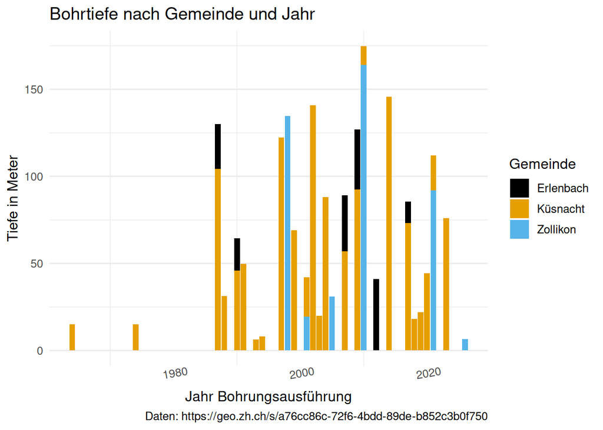

```r
ggplot(
  data = Sondierbohrungen,
  mapping = aes(x = Jahr, y = Bohrtiefe_m, fill = Gemeinde)
) +
  geom_col(na.rm = TRUE) +
  scale_fill_colorblind() +
  labs(
    title = "Bohrtiefe nach Gemeinde und Jahr",
    x = "Jahr Bohrungsausführung",
    y = "Tiefe in Meter",
    caption = "Daten: https://geo.zh.ch/s/a76cc86c-72f6-4bdd-89de-b852c3b0f750",
    fill = "Gemeinde"
  ) +
  theme_minimal(base_size = 12) +
      scale_color_manual(values = zhpal$zhwebaccent) +
  theme(
    panel.grid.major.x = element_blank(),
    axis.text.x = element_text(angle = 10, vjust = 1.5)
  )
```

*Anzahl Sondierungen pro Gemeinde*

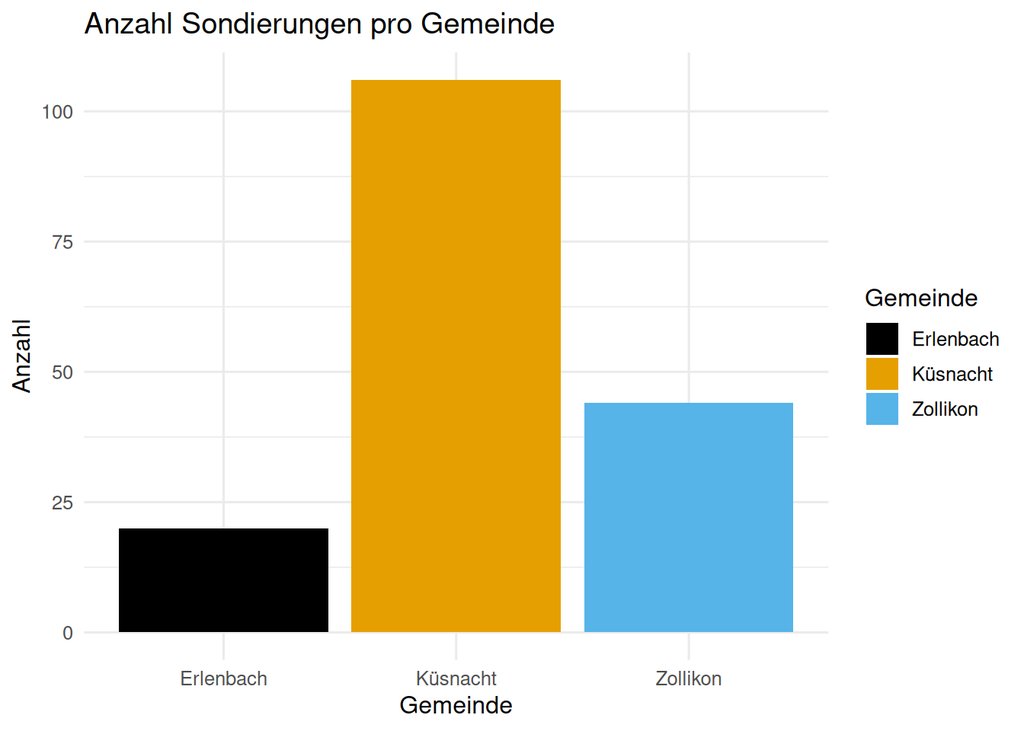

```r
ggplot(
  data = Sondierbohrungen,
  mapping = aes(x = Gemeinde, fill = Gemeinde)
) +
  geom_bar() +
  scale_fill_colorblind() +
  labs(title = "Anzahl Sondierungen pro Gemeinde", y = "Anzahl") +
  theme_minimal(base_size = 12)
```

*Grundwasserspiegel auswerten*

Mittlerer Grundwasserspiegel pro Gemeinde und Jahr.

```r
gws_pro_jahr <-
  Sondierbohrungen |>
  summarise(
    GWS = mean(Grundwasserspiegelkote, na.rm = TRUE),
    .by = c(Gemeinde, Jahr)
  )
```

```r
  kable(gws_pro_jahr, caption = "Tabelle 3: Messwerte mittlerer Grundwasserspiegel pro Gemeinde und Jahr") |>
  kable_styling(bootstrap_options = c("striped", "hover"))
```

Tabelle 3: Messwerte mittlerer Grundwasserspiegel pro Gemeinde und Jahr

| Gemeinde | Jahr | GWS |
| --- | --- | --- |
| Zollikon | 2026 | NaN |
| Zollikon | 2001 | 532.2067 |
| Zollikon | 2021 | 423.5333 |
| Zollikon | 1998 | 474.5879 |
| Zollikon | 2010 | 587.7350 |
| Zollikon | 2005 | 593.7367 |
| Küsnacht | 1964 | 414.0000 |
| Küsnacht | 2004 | 412.4033 |
| Küsnacht | 2009 | 408.9200 |
| Küsnacht | 1997 | 409.2214 |
| Küsnacht | NA | 412.0000 |
| Küsnacht | 2014 | 408.0033 |
| Küsnacht | 2019 | 408.8200 |
| Küsnacht | 2023 | 506.0250 |
| Küsnacht | 2021 | 656.1850 |
| Küsnacht | 1974 | 411.0000 |
| Küsnacht | 1994 | 656.0000 |
| Küsnacht | 2020 | NaN |
| Küsnacht | 2017 | 415.3329 |
| Küsnacht | 1987 | 469.1783 |
| Küsnacht | 2018 | 408.6250 |
| Küsnacht | 1960 | NaN |
| Küsnacht | 2010 | 533.0000 |
| Küsnacht | 2002 | 406.4340 |
| Küsnacht | 2003 | 405.9400 |
| Küsnacht | 2001 | 405.7433 |
| Küsnacht | 2007 | 406.0183 |
| Küsnacht | 1999 | 442.4167 |
| Küsnacht | 1990 | 526.1467 |
| Küsnacht | 1991 | 408.1975 |
| Küsnacht | 1988 | 410.8000 |
| Küsnacht | 1993 | 406.7500 |
| Erlenbach | 2007 | 515.1775 |
| Erlenbach | 2024 | 412.5800 |
| Erlenbach | 1987 | 666.7000 |
| Erlenbach | 2017 | 408.1500 |
| Erlenbach | 2012 | 406.3667 |
| Erlenbach | 2009 | 409.7867 |
| Erlenbach | 1990 | 462.9900 |

*Anzahl der Sondierungen pro Gemeinde und mittlerer Grundwasserspiegel*

```r
eval = FALSE
mgs_Gemeinde<-
  Sondierbohrungen |>
  summarise(
    anzahl = n(),
    GWS = mean(Grundwasserspiegelkote, na.rm = TRUE),
    .by = Gemeinde
  )
```

```r
  kable(mgs_Gemeinde, caption = "Tabelle 3: Anzahl der Sondierungen pro Gemeinde und mittlerer Grundwasserspiegel") |>
  kable_styling(bootstrap_options = c("striped", "hover"))
```

Tabelle 3: Anzahl der Sondierungen pro Gemeinde und mittlerer Grundwasserspiegel

| Gemeinde | anzahl | GWS |
| --- | --- | --- |
| Zollikon | 44 | 530.6774 |
| Küsnacht | 106 | 431.2829 |
| Erlenbach | 20 | 458.7061 |

*Grundwasserspiegel pro Gemeinde als Boxplot*

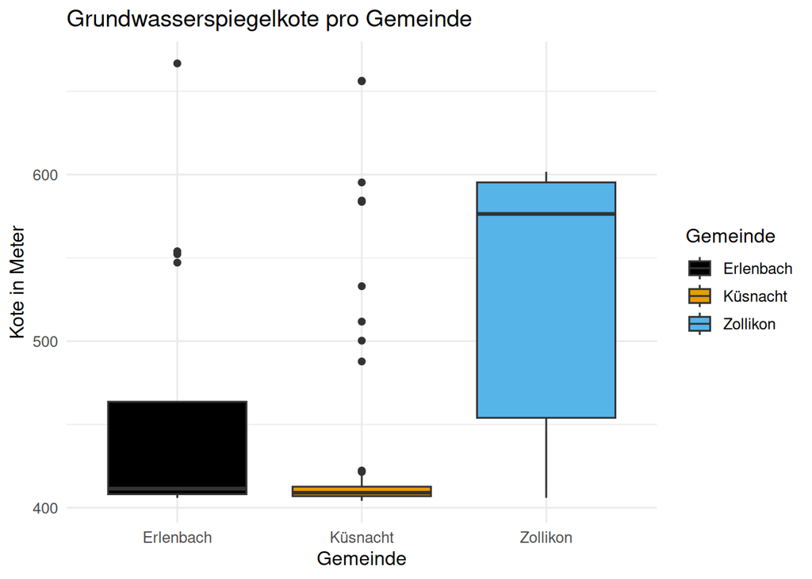

```r
ggplot(
  data = Sondierbohrungen,
  mapping = aes(x = Gemeinde, y = Grundwasserspiegelkote, fill = Gemeinde)
) +
  geom_boxplot() +
  scale_fill_colorblind() +
  labs(title = "Grundwasserspiegelkote pro Gemeinde", y = "Kote in Meter") +
  theme_minimal(base_size = 12)
```

*Grundwasserspiegel über die Jahre, mit Trendlinie pro Gemeinde*

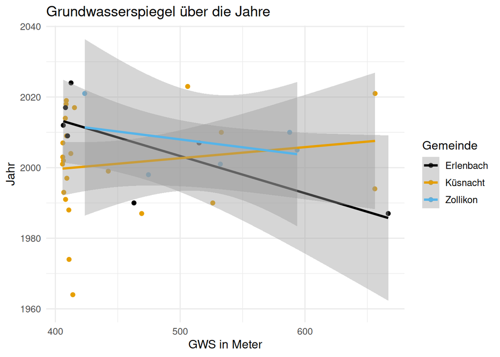

```r
ggplot(
  data = gws_pro_jahr,
  mapping = aes(x = GWS, y = Jahr, colour = Gemeinde)
) +
  geom_point() +
  geom_smooth(method = "lm", formula = y ~ x) +
  scale_colour_colorblind() +
  labs(title = "Grundwasserspiegel über die Jahre", x = "GWS in Meter") +
  theme_minimal(base_size = 12)
```

*Bohrtiefe und Ausführungsjahr*

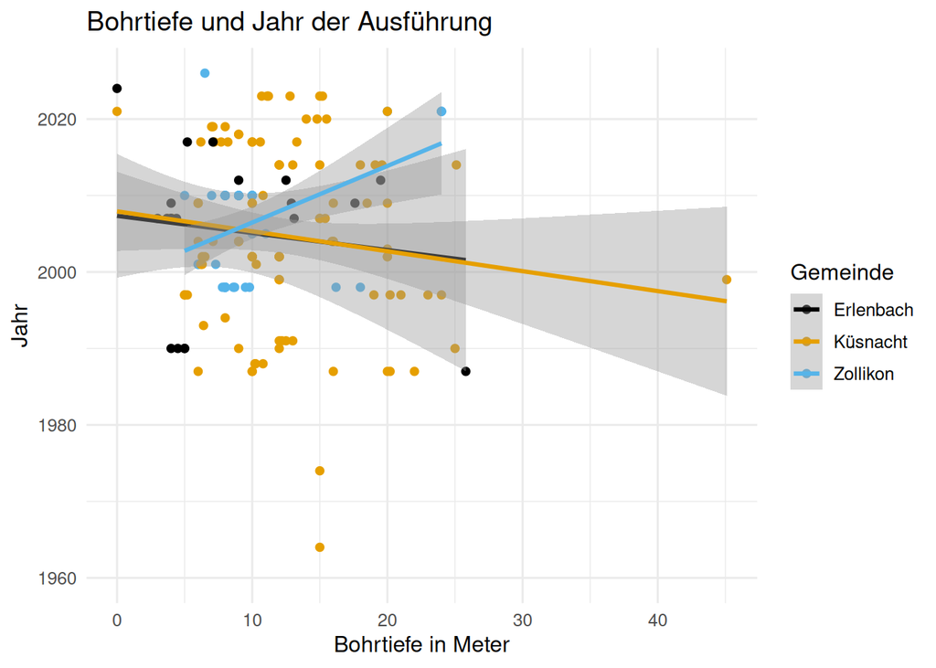

```r
ggplot(
  data = Sondierbohrungen,
  mapping = aes(x = Bohrtiefe_m, y = Jahr, colour = Gemeinde)
) +
  geom_point(na.rm = TRUE) +
  geom_smooth(method = "lm", formula = y ~ x, na.rm = TRUE) +
  scale_colour_colorblind() +
  labs(title = "Bohrtiefe und Jahr der Ausführung", x = "Bohrtiefe in Meter") +
  theme_minimal(base_size = 12)
```

## 4 Karte der Sondierbohrungen

Aus den Koordinaten (LV95, EPSG:2056) bauen wir ein `sf`-Objekt und stellen die Bohrungen als Karte dar. Wichtig: bei `coords` kommt der Ostwert (east) zuerst, dann der Nordwert (north).

```r
sondierungen_sf1 <- Sondierbohrungen |>
  filter(!is.na(east_coordinate_lv95), !is.na(north_coordinate_lv95)) |>
  st_as_sf(
    coords = c("east_coordinate_lv95", "north_coordinate_lv95"),
    crs = 2056
  )
```

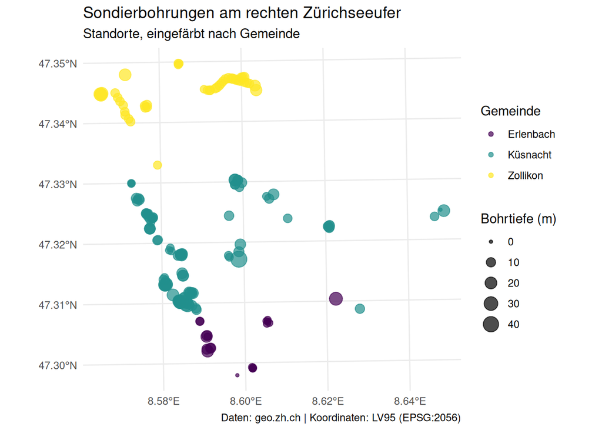

```r
ggplot(data = sondierungen_sf1) +
  geom_sf(aes(color = Gemeinde, size = Bohrtiefe_m), alpha = 0.7) +
  scale_color_viridis_d() +
  labs(
    title = "Sondierbohrungen am rechten Zürichseeufer",
    subtitle = "Standorte, eingefärbt nach Gemeinde",
    color = "Gemeinde",
    size = "Bohrtiefe (m)",
    caption = "Daten: geo.zh.ch | Koordinaten: LV95 (EPSG:2056)"
  ) +
  theme_minimal()
```

*Tabelle mit Koordinaten*

```r
Sondierbohrungen |>
  filter(!is.na(Grundwasserspiegelkote)) |>
  group_by(Gemeinde) |>
  gt::gt() |>
  gt::fmt_number(columns = c(Grundwasserspiegelkote),
             decimals = 1)
```

Koordianaten, Gemeinden, Jahr, GWS.

| east_coordinate_lv95 | north_coordinate_lv95 | Terrainkote_m | Jahr | Bohrtiefe_m | Felstiefe | Grundwasserspiegelkote | Flurabstand_m | Firma |
| --- | --- | --- | --- | --- | --- | --- | --- | --- |
| Zollikon |  |  |  |  |  |  |  |  |
| 2686593 | 1244955 | 534.03 | 2001 | 7.30 | NA | 532.1 | 1.90 | Jäckli Geologie AG |
| 2685614 | 1244746 | 461.94 | 2021 | 20.00 | 18.20 | 458.3 | 3.60 | Dr. von Moos AG |
| 2685156 | 1244389 | 407.19 | 2021 | 24.00 | 21.70 | 406.0 | 1.21 | Dr. von Moos AG |
| 2685182 | 1244398 | 408.04 | 2021 | 24.00 | 20.95 | 406.3 | 1.76 | Dr. von Moos AG |
| 2688029 | 1244464 | 610.68 | 1998 | 18.00 | NA | 596.3 | 14.37 | Dr. von Moos AG, Zürich |
| 2688006 | 1244547 | 605.73 | 1998 | 16.20 | NA | 596.0 | 9.70 | Dr. von Moos AG, Zürich |
| 2687858 | 1244599 | 604.47 | 2010 | 9.00 | NA | 601.5 | 3.01 | Jäckli Geologie AG |
| 2687813 | 1244612 | 604.11 | 2010 | 9.00 | NA | 600.7 | 3.42 | Jäckli Geologie AG |
| 2687737 | 1244633 | 603.38 | 2010 | 9.00 | NA | 601.7 | 1.72 | Jäckli Geologie AG |
| 2687699 | 1244644 | 603.06 | 2010 | 10.00 | NA | 600.4 | 2.62 | Jäckli Geologie AG |
| 2687654 | 1244657 | 602.65 | 2010 | 10.00 | NA | 595.4 | 7.30 | Jäckli Geologie AG |
| 2687603 | 1244671 | 602.21 | 2010 | 10.00 | NA | 595.7 | 6.52 | Jäckli Geologie AG |
| 2687574 | 1244679 | 601.85 | 2010 | 10.00 | NA | 595.7 | 6.16 | Jäckli Geologie AG |
| 2687518 | 1244685 | 600.82 | 2010 | 10.00 | NA | 597.0 | 3.87 | Jäckli Geologie AG |
| 2687385 | 1244588 | 592.63 | 2010 | 8.00 | NA | 585.9 | 6.78 | Jäckli Geologie AG |
| 2687349 | 1244549 | 590.16 | 2010 | 9.00 | NA | 588.0 | 2.16 | Jäckli Geologie AG |
| 2687308 | 1244513 | 588.02 | 2010 | 9.00 | NA | 586.6 | 1.37 | Jäckli Geologie AG |
| 2687273 | 1244492 | 587.14 | 2010 | 8.00 | NA | 585.6 | 1.53 | Jäckli Geologie AG |
| 2687184 | 1244462 | 585.57 | 2010 | 8.00 | NA | 528.9 | 56.68 | Jäckli Geologie AG |
| 2687170 | 1244460 | 585.30 | 2010 | 8.00 | NA | 582.9 | 2.39 | Jäckli Geologie AG |
| 2687129 | 1244462 | 583.17 | 2010 | 7.00 | NA | 581.6 | 1.61 | Jäckli Geologie AG |
| 2687066 | 1244480 | 579.20 | 2010 | 5.00 | NA | 576.4 | 2.84 | Jäckli Geologie AG |
| 2687808 | 1244704 | 596.96 | 2005 | 11.00 | NA | 593.7 | 3.25 | Jäckli Geologie AG |
| 2687782 | 1244698 | 597.66 | 2005 | 10.00 | NA | 592.3 | 5.40 | Jäckli Geologie AG |
| 2687755 | 1244694 | 598.74 | 2005 | 10.00 | NA | 595.2 | 3.50 | Jäckli Geologie AG |
| 2686593 | 1244930 | 534.01 | 2001 | 6.00 | NA | 531.5 | 2.47 | Jäckli Geologie AG |
| 2686610 | 1244953 | 535.85 | 2001 | 6.00 | NA | 533.0 | 2.90 | Jäckli Geologie AG |
| 2685617 | 1244003 | 450.95 | 1998 | 8.60 | NA | 443.2 | 7.76 | Jäckli Geologie AG Zürich |
| 2685608 | 1244065 | 449.85 | 1998 | 8.00 | NA | 444.6 | 5.20 | Jäckli Geologie AG Zürich |

[output cut: 115 more lines]

*Grundwasserspiegelkoten*

Abbildung 1: Grundwasserspiegel in den Gemeinden Erlenbach, Küsnacht und Zollikon

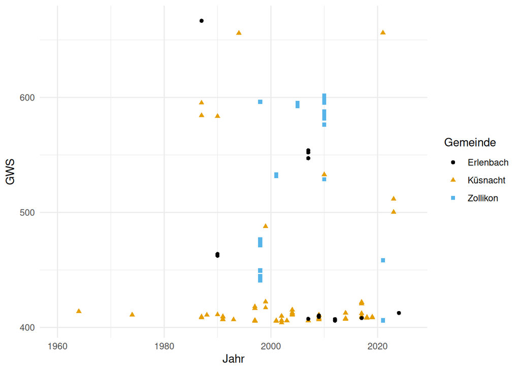

```r
ggplot(data = Sondierbohrungen,
       mapping = aes(x = Jahr,
                     y = Grundwasserspiegelkote,
                     color = Gemeinde,
                     shape = Gemeinde)) +
  geom_point() +
  scale_color_colorblind() +
  labs(x = "Jahr", y = "GWS") +
  theme_minimal()
```

## 5 Schlussfolgerung: Interaktive Karte mit tmap

*In ein sf-Objekt umwandeln*

Wir behalten nur Zeilen mit gültigen Koordinaten und bauen daraus ein `sf`-Objekt. Das Koordinatensystem ist LV95 (CH1903+), EPSG-Code 2056. Bei `coords` kommt der Ostwert (east) zuerst, dann der Nordwert (north).

```r
sondierungen_sf <- Sondierbohrungen |>
  filter(!is.na(east_coordinate_lv95), !is.na(north_coordinate_lv95)) |>
  st_as_sf(
    coords = c("east_coordinate_lv95", "north_coordinate_lv95"),
    crs = 2056
  )

sondierungen_sf
```

```
Simple feature collection with 170 features and 8 fields
Geometry type: POINT
Dimension:     XY
Bounding box:  xmin: 2685156 ymin: 1239210 xmax: 2691486 ymax: 1244955
Projected CRS: CH1903+ / LV95
# A tibble: 170 × 9
   Gemeinde Terrainkote_m  Jahr Bohrtiefe_m Felstiefe Grundwasserspiegelkote
 * <chr>            <dbl> <dbl>       <dbl>     <dbl>                  <dbl>
 1 Zollikon          476.  2026         6.5      NA                      NA
 2 Zollikon          534.  2001         7.3      NA                     532.
 3 Zollikon          462.  2021        20        18.2                   458.
 4 Zollikon          407.  2021        24        21.7                   406.
 5 Zollikon          407.  2021        24        22.4                    NA
 6 Zollikon          408.  2021        24        21.0                   406.
 7 Zollikon          611.  1998        18        NA                     596.
 8 Zollikon          606.  1998        16.2      NA                     596.
 9 Zollikon          605.  2010         8        NA                      NA
10 Zollikon          604.  2010         9        NA                     601.
# ℹ 160 more rows
# ℹ 3 more variables: Flurabstand_m <dbl>, Firma <chr>, geometry <POINT [m]>
```

```r
library(tmap)
tmap_mode("view")
tm_shape(sondierungen_sf1) +
  tm_dots(fill = "Gemeinde", size = "Bohrtiefe_m")
```

[interactive chart not shown]